# **Problem Statement**

## Business Context

A sales forecast is a prediction of future sales revenue based on historical data, industry trends, and the status of the current sales pipeline. Businesses use the sales forecast to estimate weekly, monthly, quarterly, and annual sales totals. A company needs to make an accurate sales forecast as it adds value across an organization and helps the different verticals to chalk out their future course of action.

Forecasting helps an organization plan its sales operations by region and provides valuable insights to the supply chain team regarding the procurement of goods and materials. An accurate sales forecast process has many benefits which include improved decision-making about the future and reduction of sales pipeline and forecast risks. Moreover, it helps to reduce the time spent in planning territory coverage and establish benchmarks that can be used to assess trends in the future.

## Objective

SuperKart is a retail chain operating supermarkets and food marts across various tier cities, offering a wide range of products. To optimize its inventory management and make informed decisions around regional sales strategies, SuperKart wants to accurately forecast the sales revenue of its outlets for the upcoming quarter.

To operationalize these insights at scale, the company has partnered with a data science firm, not just to build a predictive model based on historical sales data but also to develop and deploy a robust forecasting solution that can be integrated into SuperKart’s decision-making systems and used across its network of stores.

## Data Description

The data contains the different attributes of the various products and stores.The detailed data dictionary is given below.

- **Product_Id** - unique identifier of each product, each identifier having two letters at the beginning followed by a number.
- **Product_Weight** - weight of each product
- **Product_Sugar_Content** - sugar content of each product like low sugar, regular and no sugar
- **Product_Allocated_Area** - ratio of the allocated display area of each product to the total display area of all the products in a store
- **Product_Type** - broad category for each product like meat, snack foods, hard drinks, dairy, canned, soft drinks, health and hygiene, baking goods, bread, breakfast, frozen foods, fruits and vegetables, household, seafood, starchy foods, others
- **Product_MRP** - maximum retail price of each product
- **Store_Id** - unique identifier of each store
- **Store_Establishment_Year** - year in which the store was established
- **Store_Size** - size of the store depending on sq. feet like high, medium and low
- **Store_Location_City_Type** - type of city in which the store is located like Tier 1, Tier 2 and Tier 3. Tier 1 consists of cities where the standard of living is comparatively higher than its Tier 2 and Tier 3 counterparts.
- **Store_Type** - type of store depending on the products that are being sold there like Departmental Store, Supermarket Type 1, Supermarket Type 2 and Food Mart
- **Product_Store_Sales_Total** - total revenue generated by the sale of that particular product in that particular store

# **Installing and Importing the necessary libraries**

```python
#Installing the libraries with the specified versions
!.venv/bin/python3 -m pip install numpy==2.0.2 pandas==2.2.2 scikit-learn==1.6.1 matplotlib==3.10.0 seaborn==0.13.2 joblib==1.4.2 xgboost==2.1.4 requests==2.32.3 huggingface_hub==0.30.1 -q
```

**Note:**

- After running the above cell, kindly restart the notebook kernel (for Jupyter Notebook) or runtime (for Google Colab) and run all cells sequentially from the next cell.
- On executing the above line of code, you might see a warning regarding package dependencies. This error message can be ignored as the above code ensures that all necessary libraries and their dependencies are maintained to successfully execute the code in this notebook.

```python
import warnings
warnings.filterwarnings("ignore")

# Libraries to help with reading and manipulating data
import numpy as np
import pandas as pd

# For splitting the dataset
from sklearn.model_selection import train_test_split

# Libaries to help with data visualization
import matplotlib.pyplot as plt
import seaborn as sns

# Removes the limit for the number of displayed columns
pd.set_option("display.max_columns", None)
# Sets the limit for the number of displayed rows
pd.set_option("display.max_rows", 100)


# Libraries different ensemble classifiers
from sklearn.ensemble import (
    BaggingRegressor,
    RandomForestRegressor,
    AdaBoostRegressor,
    GradientBoostingRegressor,
)
from xgboost import XGBRegressor
from sklearn.tree import DecisionTreeRegressor

# Libraries to get different metric scores
from sklearn.metrics import (
    confusion_matrix,
    accuracy_score,
    precision_score,
    recall_score,
    f1_score,
    mean_squared_error,
    mean_absolute_error,
    r2_score,
    mean_absolute_percentage_error
)

from sklearn.impute import SimpleImputer
from sklearn.preprocessing import StandardScaler, OneHotEncoder

# To check feature importance
from sklearn.model_selection import cross_val_score
from sklearn.preprocessing import LabelEncoder
from datetime import datetime

# To create the pipeline
from sklearn.compose import make_column_transformer
from sklearn.pipeline import make_pipeline,Pipeline

# To tune different models and standardize
from sklearn.model_selection import GridSearchCV
from sklearn.preprocessing import StandardScaler,OneHotEncoder

from sklearn import metrics
from sklearn.compose import TransformedTargetRegressor

# To serialize the model
import joblib

# os related functionalities
import os

# API request
import requests

# for hugging face space authentication to upload files
from huggingface_hub import login, HfApi
```

# **Loading the dataset**

```python
# Load the dataset from a CSV file into a Pandas DataFrame
superkart_data = pd.read_csv("SuperKart.csv")
```

```python
# Create a copy of the dataframe
dataset = superkart_data.copy()
```

# **Data Overview**

#### View the first and last 5 rows of the dataset

```python
# Display the first five rows of the dataset
dataset.head()
```

|  | Product_Id | Product_Weight | Product_Sugar_Content | Product_Allocated_Area | Product_Type | Product_MRP | Store_Id | Store_Establishment_Year | Store_Size | Store_Location_City_Type | Store_Type | Product_Store_Sales_Total |
| --- | --- | --- | --- | --- | --- | --- | --- | --- | --- | --- | --- | --- |
| 0 | FD6114 | 12.66 | Low Sugar | 0.027 | Frozen Foods | 117.08 | OUT004 | 2009 | Medium | Tier 2 | Supermarket Type2 | 2842.40 |
| 1 | FD7839 | 16.54 | Low Sugar | 0.144 | Dairy | 171.43 | OUT003 | 1999 | Medium | Tier 1 | Departmental Store | 4830.02 |
| 2 | FD5075 | 14.28 | Regular | 0.031 | Canned | 162.08 | OUT001 | 1987 | High | Tier 2 | Supermarket Type1 | 4130.16 |
| 3 | FD8233 | 12.10 | Low Sugar | 0.112 | Baking Goods | 186.31 | OUT001 | 1987 | High | Tier 2 | Supermarket Type1 | 4132.18 |
| 4 | NC1180 | 9.57 | No Sugar | 0.010 | Health and Hygiene | 123.67 | OUT002 | 1998 | Small | Tier 3 | Food Mart | 2279.36 |

```python
# Display the last five rows of the dataset
dataset.tail()
```

|  | Product_Id | Product_Weight | Product_Sugar_Content | Product_Allocated_Area | Product_Type | Product_MRP | Store_Id | Store_Establishment_Year | Store_Size | Store_Location_City_Type | Store_Type | Product_Store_Sales_Total |
| --- | --- | --- | --- | --- | --- | --- | --- | --- | --- | --- | --- | --- |
| 8758 | NC7546 | 14.80 | No Sugar | 0.016 | Health and Hygiene | 140.53 | OUT004 | 2009 | Medium | Tier 2 | Supermarket Type2 | 3806.53 |
| 8759 | NC584 | 14.06 | No Sugar | 0.142 | Household | 144.51 | OUT004 | 2009 | Medium | Tier 2 | Supermarket Type2 | 5020.74 |
| 8760 | NC2471 | 13.48 | No Sugar | 0.017 | Health and Hygiene | 88.58 | OUT001 | 1987 | High | Tier 2 | Supermarket Type1 | 2443.42 |
| 8761 | NC7187 | 13.89 | No Sugar | 0.193 | Household | 168.44 | OUT001 | 1987 | High | Tier 2 | Supermarket Type1 | 4171.82 |
| 8762 | FD306 | 14.73 | Low Sugar | 0.177 | Snack Foods | 224.93 | OUT002 | 1998 | Small | Tier 3 | Food Mart | 2186.08 |

#### Understand the shape of the dataset

```python
# checking shape of the data
print(f"There are {dataset.shape[0]} rows and {dataset.shape[1]} columns.")
```

```
There are 8763 rows and 12 columns.
```

#### Check the data types of the columns for the dataset

```python
# checking column datatypes and number of non-null values
dataset.info()
```

```
<class 'pandas.core.frame.DataFrame'>
RangeIndex: 8763 entries, 0 to 8762
Data columns (total 12 columns):
 #   Column                     Non-Null Count  Dtype
---  ------                     --------------  -----
 0   Product_Id                 8763 non-null   object
 1   Product_Weight             8763 non-null   float64
 2   Product_Sugar_Content      8763 non-null   object
 3   Product_Allocated_Area     8763 non-null   float64
 4   Product_Type               8763 non-null   object
 5   Product_MRP                8763 non-null   float64
 6   Store_Id                   8763 non-null   object
 7   Store_Establishment_Year   8763 non-null   int64
 8   Store_Size                 8763 non-null   object
 9   Store_Location_City_Type   8763 non-null   object
 10  Store_Type                 8763 non-null   object
 11  Product_Store_Sales_Total  8763 non-null   float64
dtypes: float64(4), int64(1), object(7)
memory usage: 821.7+ KB
```

**Observation**

- `Product_Weight`, `Product_Allocated_area`, `Product_MRP`, `Store_Establishment_Year` and `Product_Store_Sales_Total` are numerical features.
- All other features are categorical type.
- No null values in any of the features.

#### Check for duplicated values or missing data

```python
# checking for duplicate values
dataset.duplicated().sum()
```

```
np.int64(0)
```

- There are no duplicate values in the data.

```python
# checking for missing values
dataset.isnull().sum()
```

```
Product_Id                   0
Product_Weight               0
Product_Sugar_Content        0
Product_Allocated_Area       0
Product_Type                 0
Product_MRP                  0
Store_Id                     0
Store_Establishment_Year     0
Store_Size                   0
Store_Location_City_Type     0
Store_Type                   0
Product_Store_Sales_Total    0
dtype: int64
```

- There are no missing values in either numerical or categorical columns.

#### Check the statistical summary of the data

```python
dataset.describe().T
```

|  | count | mean | std | min | 25% | 50% | 75% | max |
| --- | --- | --- | --- | --- | --- | --- | --- | --- |
| Product_Weight | 8763.0 | 12.653792 | 2.217320 | 4.000 | 11.150 | 12.660 | 14.180 | 22.000 |
| Product_Allocated_Area | 8763.0 | 0.068786 | 0.048204 | 0.004 | 0.031 | 0.056 | 0.096 | 0.298 |
| Product_MRP | 8763.0 | 147.032539 | 30.694110 | 31.000 | 126.160 | 146.740 | 167.585 | 266.000 |
| Store_Establishment_Year | 8763.0 | 2002.032751 | 8.388381 | 1987.000 | 1998.000 | 2009.000 | 2009.000 | 2009.000 |
| Product_Store_Sales_Total | 8763.0 | 3464.003640 | 1065.630494 | 33.000 | 2761.715 | 3452.340 | 4145.165 | 8000.000 |

**Observations**

# **Exploratory Data Analysis (EDA)**

Let's start by defining the target and predictor (numerical and categorical) variables.

- We have two Id based columns (Product_Id and Store_Id), lets see if either one is unique for each data row

```python
dataset['Product_Id'].nunique()
```

```
8763
```

```python
dataset['Store_Id'].nunique()
```

```
4
```

```python
dataset.drop(["Product_Id"], axis=1, inplace=True)
```

- We'll drop the `Product_Id` attribute as it serves only as a unique identifier (`# data rows = Product_Id unique values`) and does not add value to the analysis and modeling.
- `Store_Id` on the other hand has only 4 unique values suggesting that we can not drop this.

```python
# Define the target variable for the regression task
target = 'Product_Store_Sales_Total'        # Total revenue generated by the sale of a particular product in a particular store

# List of numerical features in the dataset (excluding 'Product_Id' as it is an identifier)
numeric_features = [
    'Product_Weight',                       # Weight of each product
    'Product_Allocated_Area',               # Display area of product / Total display area of all the products in a store
    'Product_MRP',                          # Maximum retail price of each product
    'Store_Establishment_Year'              # Year in which the store was established
]

# List of categorical features in the dataset
categorical_features = [
    'Product_Sugar_Content',             # Low sugar, Regular or No sugar
    'Product_Type',                      # Broad category for each product like meat, snack foods, hard drinks, dairy, canned, soft drinks etc.
    'Store_Id',                          # Unique identifier of each store
    'Store_Size',                        # Size of the store depending on sq footage (high, medium or low)
    'Store_Location_City_Type',          # Type of city in which the store is located (Tier 1, Tier 2 and Tier 3)
    'Store_Type'                         # Type of store depending on the products that are being sold there (Departmental Store, Supermarket Type 1, Supermarket Type 2 and Food Mart)
]
```

#### Let's check the count of each unique category in each of the categorical variables

```python
# Making a list of all categorical variables
cat_col = list(dataset.select_dtypes("object").columns)

# Printing number of count of each unique value in each column
for column in cat_col:
    print(dataset[column].value_counts())
    print("-" * 50)
```

```
Product_Sugar_Content
Low Sugar    4885
Regular      2251
No Sugar     1519
reg           108
Name: count, dtype: int64
--------------------------------------------------
Product_Type
Fruits and Vegetables    1249
Snack Foods              1149
Frozen Foods              811
Dairy                     796
Household                 740
Baking Goods              716
Canned                    677
Health and Hygiene        628
Meat                      618
Soft Drinks               519
Breads                    200
Hard Drinks               186
Others                    151
Starchy Foods             141
Breakfast                 106
Seafood                    76
Name: count, dtype: int64
--------------------------------------------------
Store_Id
OUT004    4676
OUT001    1586
OUT003    1349
OUT002    1152
Name: count, dtype: int64
--------------------------------------------------
Store_Size
Medium    6025
High      1586
Small     1152
Name: count, dtype: int64
--------------------------------------------------
Store_Location_City_Type
Tier 2    6262
Tier 1    1349
Tier 3    1152
Name: count, dtype: int64
--------------------------------------------------
Store_Type
Supermarket Type2     4676
Supermarket Type1     1586
Departmental Store    1349
Food Mart             1152
Name: count, dtype: int64
--------------------------------------------------
```

**Observations**

#### Utility functions

```python
# function to create labeled barplots


def labeled_barplot(data, feature, perc=False, n=None):
    """
    Barplot with percentage at the top

    data: dataframe
    feature: dataframe column
    perc: whether to display percentages instead of count (default is False)
    n: displays the top n category levels (default is None, i.e., display all levels)
    """

    total = len(data[feature])  # length of the column
    count = data[feature].nunique()
    if n is None:
        plt.figure(figsize=(count + 1, 5))
    else:
        plt.figure(figsize=(n + 1, 5))

    plt.xticks(rotation=90, fontsize=15)
    ax = sns.countplot(
        data=data,
        x=feature,
        palette="Paired",
        order=data[feature].value_counts().index[:n].sort_values(),
    )

    for p in ax.patches:
        if perc == True:
            label = "{:.1f}%".format(
                100 * p.get_height() / total
            )  # percentage of each class of the category
        else:
            label = p.get_height()  # count of each level of the category

        x = p.get_x() + p.get_width() / 2  # width of the plot
        y = p.get_height()  # height of the plot

        ax.annotate(
            label,
            (x, y),
            ha="center",
            va="center",
            size=12,
            xytext=(0, 5),
            textcoords="offset points",
        )  # annotate the percentage

    plt.show()  # show the plot

def stacked_barplot(data, predictor, target):
    """
    Print the category counts and plot a stacked bar chart

    data: dataframe
    predictor: independent variable
    target: target variable
    """
    count = data[predictor].nunique()
    sorter = data[target].value_counts().index[-1]
    tab1 = pd.crosstab(data[predictor], data[target], margins=True).sort_values(
        by=sorter, ascending=False
    )
    print(tab1)
    print("-" * 120)
    tab = pd.crosstab(data[predictor], data[target], normalize="index").sort_values(
        by=sorter, ascending=False
    )
    tab.plot(kind="bar", stacked=True, figsize=(count + 5, 5))
    plt.legend(
        loc="lower left", frameon=False,
    )
    plt.legend(loc="upper left", bbox_to_anchor=(1, 1))
    plt.show()
```

## Univariate Analysis

#### Observations on Product_MRP

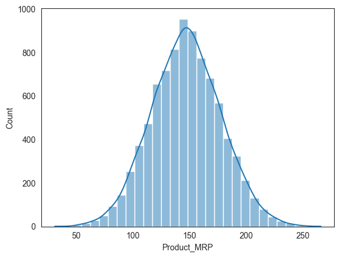

```python
sns.histplot(data=dataset, x="Product_MRP", bins=30, kde=True);
```

- The distribution is approximately symmetric with a bell-shaped KDE centered near 150, indicating minimal skew.
- Most MRPs cluster roughly between 120–180, with thin tails tapering toward about 50 and 250, implying few extreme price points.
- No secondary peaks or gaps are apparent, suggesting a single price-tier structure rather than distinct clusters.

#### Observations on Product_Allocated_Area

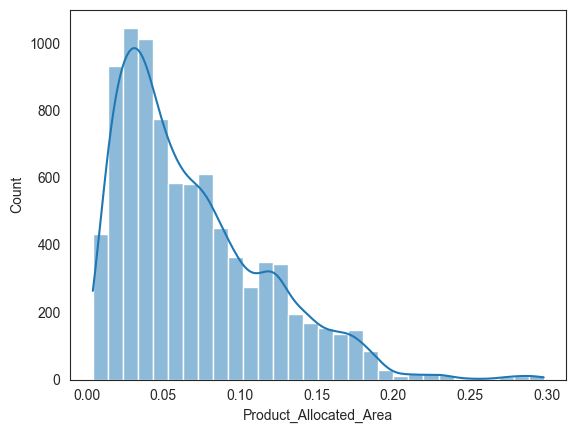

```python
sns.histplot(data=dataset, x="Product_Allocated_Area", bins=30, kde=True);
```

- Strong right skew with the mode near ~0.03 and most values around 0.02–0.08, a long tail extends to ~0.30, indicating a small set of products with disproportionately large display share.
- the thin extreme tail beyond ~0.20 suggests rare high allocations that could behave like outliers in analysis.

#### Observations on Product_Weight

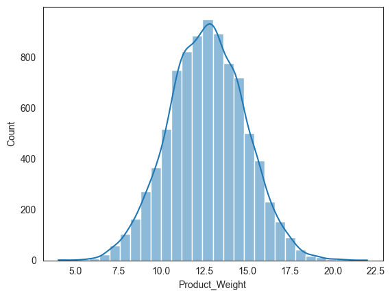

```python
sns.histplot(data=dataset, x="Product_Weight", bins=30, kde=True);
```

- Almost symmetric bell-shaped distribution centered near 12–13, indicating minimal skew.
- Most values lie around 10–15 with thin tails toward ~4 and ~22, suggesting few extremes and no secondary clusters.

#### Observations on Product_Sugar_Content

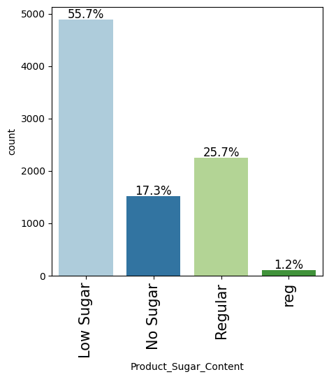

```python
labeled_barplot(dataset, "Product_Sugar_Content", perc=True)
```

- Low Sugar is the majority at about 55.7%, with Regular around 25.7% and No Sugar about 17.3%, indicating a distribution dominated by reduced-sugar options.
- A small extra category “reg” (~1.2%) likely reflects inconsistent labeling of “Regular” and should be standardized before modeling to avoid fragmented counts.

#### Observations on Product_Type

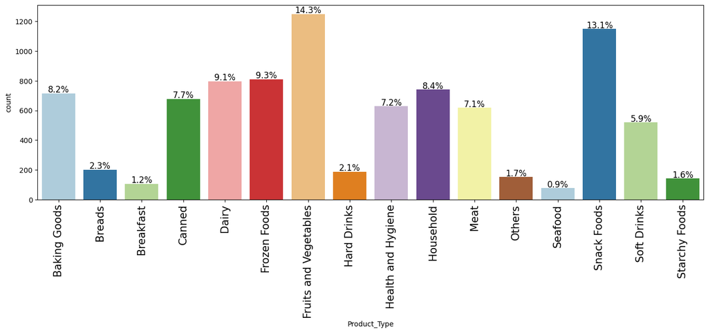

```python
labeled_barplot(dataset, "Product_Type", perc=True)
```

- Product type mix is concentrated in a few categories: Fruits & Vegetables (~14.3%) and Snack Foods (~13.1%) lead, with Frozen Foods and Dairy near 9% each.
- A mid-tier of Baking Goods, Canned, Household, Health & Hygiene, and Meat sits around 7–8%, while a long tail of low-share groups (e.g., Breads, Hard Drinks, Breakfast, Seafood) is below ~3%, suggesting a Pareto-style focus on the vital few.

#### Observations on Store_Id

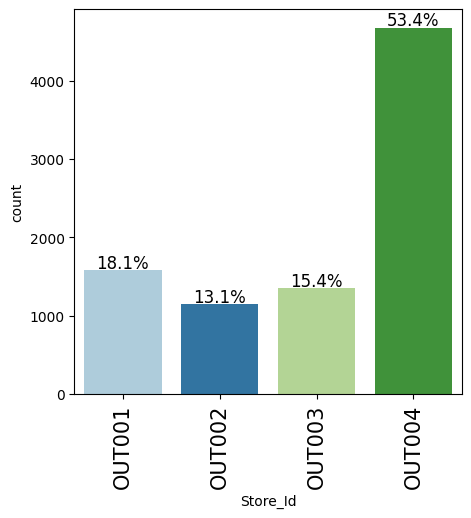

```python
labeled_barplot(dataset, "Store_Id", perc=True)
```

- Store with id OUT004 dominates with about 53.4% of records, while OUT001, OUT003, and OUT002 contribute roughly 18.1%, 15.4%, and 13.1%, indicating a strong imbalance across stores.
- This imbalance suggests analyses sensitive to store-level volume should weight or normalize by store to avoid results being driven primarily by OUT004.

#### Observations on Store_Location_City_Type

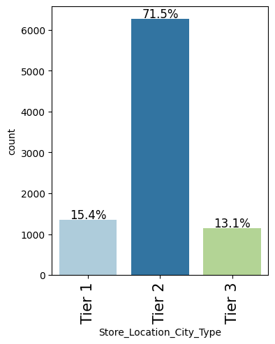

```python
labeled_barplot(dataset, "Store_Location_City_Type", perc=True)
```

- Tier 2 dominates with about 71.5% of records, while Tier 1 and Tier 3 are roughly 15.4% and 13.1%, indicating a pronounced imbalance across city tiers.
- Analyses stratified by city tier should apply weighting or stratified evaluation to avoid results being overly driven by Tier 2 representation and to mitigate sampling bias concerns.

#### Observations on Store_Size

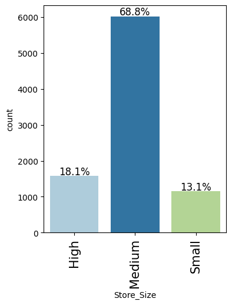

```python
labeled_barplot(dataset, "Store_Size", perc=True)
```

- Medium stores dominate at about 68.8%, with High around 18.1% and Small near 13.1%, indicating a size mix centered on medium formats.
- Any store-size analysis or modeling should account for this imbalance so insights aren’t overly influenced by the Medium segment.

#### Observations on Store_Type

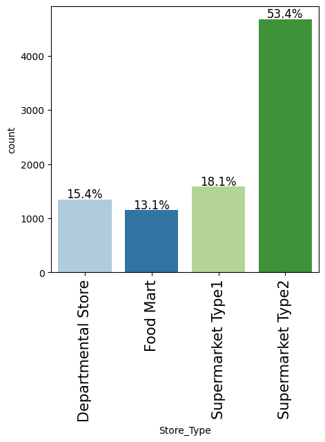

```python
labeled_barplot(dataset, "Store_Type", perc=True)
```

- Supermarket Type 2 dominates at about 53.4%, followed by Supermarket Type 1 at ~18.1%, with Departmental Store and Food Mart near 15.4% and 13.1%.
- The strong dominance of a single store type implies analyses and modeling should check for type-driven effects or weight by type to avoid overrepresentation bias.

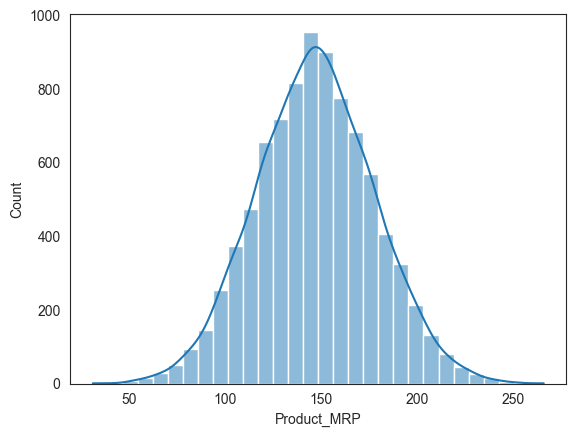

```python
sns.histplot(data=dataset, x="Product_MRP", bins=30, kde=True);
```

**Observations**

## Bivariate Analysis

#### Correlation between numerical columns

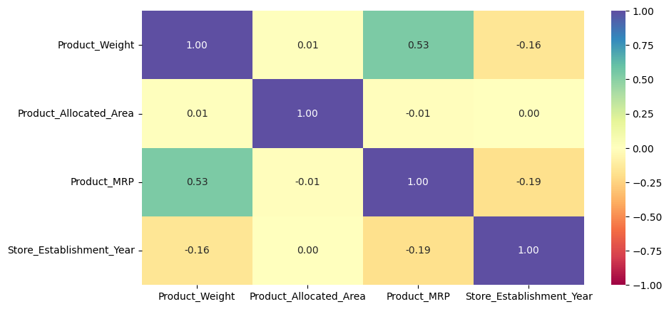

```python
plt.figure(figsize=(10, 5))
sns.heatmap(
    dataset[numeric_features].corr(), annot=True, vmin=-1, vmax=1, fmt=".2f", cmap="Spectral"
)
plt.show()
```

**Observations**

- `Product_Weight` and `Product_MRP` are moderately correlated having a positive relationship, heavier products tend to have a higher price
- All other features are either very weakly correlated or not correlated at all, suggesting that factors like display area or store age have minimal direct influence on product pricing

#### Does store Store size and store location impact product-store sales revenue ?

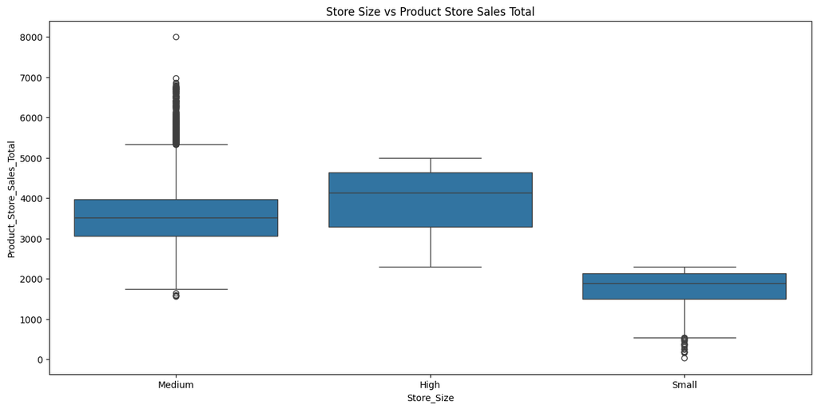

```python
# Store_Size vs Product_Store_Sales_Total
plt.figure(figsize=(15, 7))
sns.boxplot(x="Store_Size", y="Product_Store_Sales_Total", data=dataset)
plt.title("Store Size vs Product Store Sales Total")
plt.show()
```

- Median sales are highest for High stores, followed by Medium, and lowest for Small, with High also showing a wider IQR, indicating both higher central tendency and greater variability at larger store sizes.
- Small stores exhibit many low-end outliers and a compressed IQR, suggesting systematically lower and tighter sales distributions relative to larger formats.

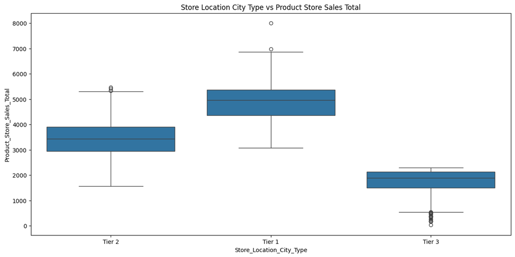

```python
# Store_Location_City_Type vs Product_Store_Sales_Total
plt.figure(figsize=(15, 7))
sns.boxplot(x="Store_Location_City_Type", y="Product_Store_Sales_Total", data=dataset)
plt.title("Store Location City Type vs Product Store Sales Total")
plt.show()
```

- Tier 1 has the highest median sales and the widest IQR, followed by Tier 2, while Tier 3 shows the lowest medians and compressed spread with several low-end outliers.
- The separation of medians across tiers indicates meaningful location differences by city tier, with Tier 1 outperforming and Tier 3 underperforming on sales distribution.

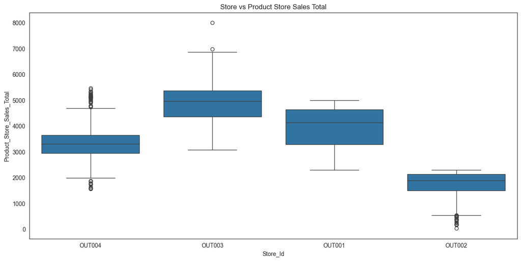

```python
# Store_Id vs Product_Store_Sales_Total
plt.figure(figsize=(15, 7))
sns.boxplot(x="Store_Id", y="Product_Store_Sales_Total", data=dataset)
plt.title("Store vs Product Store Sales Total")
plt.show()
```

- OUT003 shows the highest median sales and broad spread, followed by OUT001, OUT004 sits lower with several high-end outliers, while OUT002 has the lowest medians and many low-end outliers.
- The differing IQRs and outlier patterns indicate substantial store-level heterogeneity, suggesting store effects should be explicitly modeled or stratified.

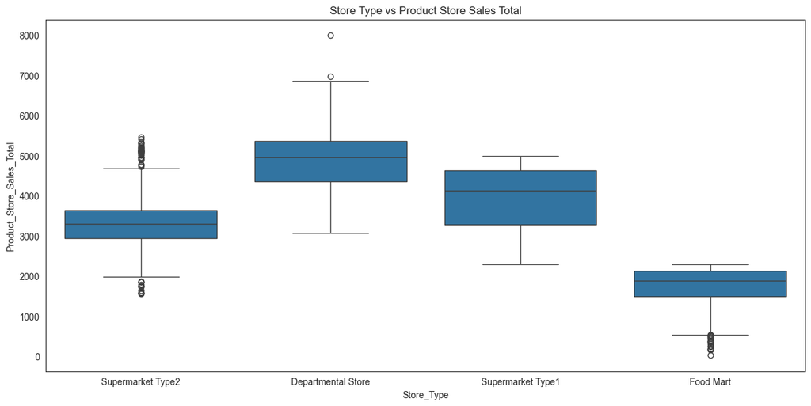

```python
# Store_Type vs Product_Store_Sales_Total
plt.figure(figsize=(15, 7))
sns.boxplot(x="Store_Type", y="Product_Store_Sales_Total", data=dataset)
plt.title("Store Type vs Product Store Sales Total")
plt.show()
```

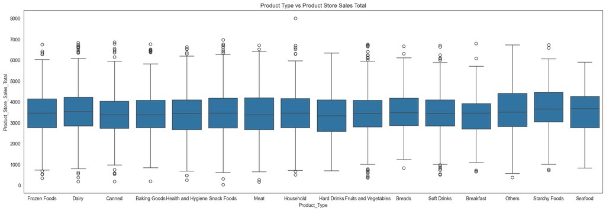

```python
# Product_Type vs Product_Store_Sales_Total
plt.figure(figsize=(22, 7))
sns.boxplot(x="Product_Type", y="Product_Store_Sales_Total", data=dataset)
plt.title("Product Type vs Product Store Sales Total")
plt.show()
```

[figure not shown]

```python
# Product_Sugar_Content vs Product_Store_Sales_Total
plt.figure(figsize=(15, 7))
sns.boxplot(x="Product_Sugar_Content", y="Product_Store_Sales_Total", data=dataset)
plt.title("Product Sugar Content vs Product Store Sales Total")
plt.show()
```

- Medians are broadly comparable across Low Sugar, Regular, and No Sugar, with similar IQRs, differences appear small relative to within-group variability.
- The extra “reg” level mirrors “Regular” and should be standardized to avoid fragmented counts and noisy estimates in modeling.

#### How does features like Product MRP, Weight, Allocated area relate to Sales ?

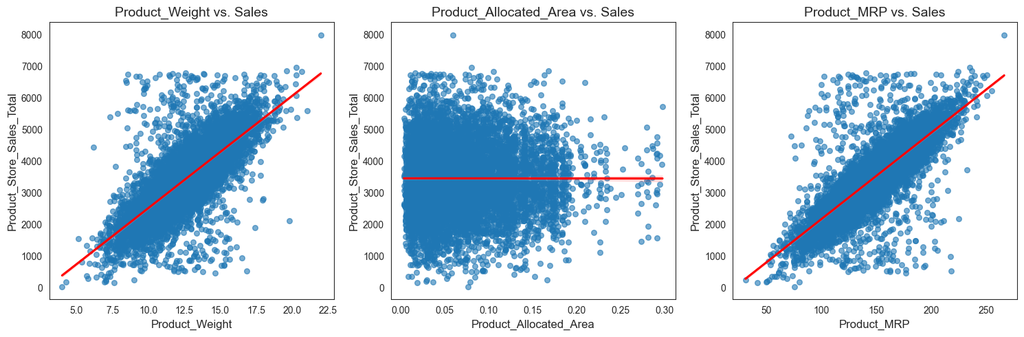

```python
features_to_plot = ['Product_Weight', 'Product_Allocated_Area', 'Product_MRP']
sns.set_style('white')
fig, axes = plt.subplots(1, len(features_to_plot),
                         figsize=(15, 5),
                         sharex=False, sharey=False)

# Flatten the array for easier indexing
ax = axes.ravel()
for i, col in enumerate(features_to_plot):
    # Seaborn regplot draws the scatter + regression line
    sns.regplot(
        x=col,
        y='Product_Store_Sales_Total',
        data=dataset,
        ax=ax[i],
        scatter_kws={'alpha':0.6, 's':30},
        line_kws={'color':'red'},
        ci=95                    # 95% confidence interval band
    )
    ax[i].set_title(f'{col} vs. Sales', fontsize=14)
    ax[i].set_xlabel(col, fontsize=12)
    ax[i].set_ylabel('Product_Store_Sales_Total', fontsize=12)

plt.tight_layout()
plt.show()
```

- Product_MRP and Product_Weight show clear positive linear relationships with sales, with tight upward trends indicating stronger associations than the other feature, higher price and heavier items tend to yield higher Product_Store_Sales_Total.
- Product_Allocated_Area exhibits near-zero slope and wide scatter, suggesting little to no linear link to sales at the product–store level in this dataset, any effect may be nonlinear or confounded by other factors.

#### Does Store establishment year affect Store size ?

```
Store_Size                High  Medium  Small   All
Store_Establishment_Year
1998                         0       0   1152  1152
All                       1586    6025   1152  8763
1987                      1586       0      0  1586
1999                         0    1349      0  1349
2009                         0    4676      0  4676
------------------------------------------------------------------------------------------------------------------------
```

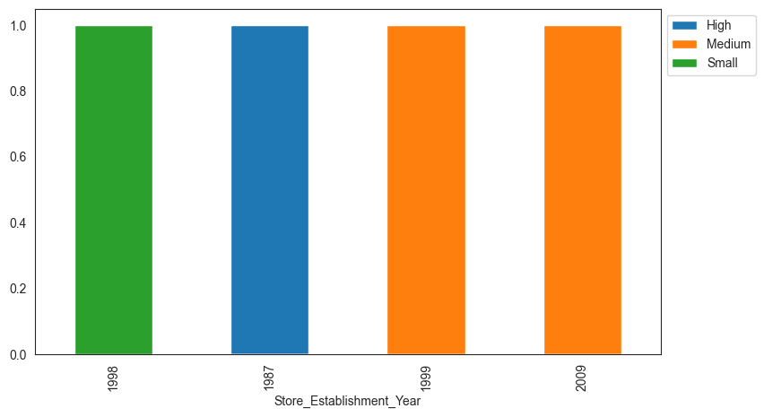

```python
stacked_barplot(dataset, "Store_Establishment_Year", "Store_Size")
```

- Across years shown (1987, 1998, 1999, 2009), Medium stores dominate counts, with High and Small present only in specific years, indicating a compositional shift by cohort rather than uniform size mix.

```
Store_Type                Departmental Store  Food Mart  Supermarket Type1  \
Store_Establishment_Year
1998                                       0       1152                  0
All                                     1349       1152               1586
1987                                       0          0               1586
1999                                    1349          0                  0
2009                                       0          0                  0

Store_Type                Supermarket Type2   All
Store_Establishment_Year
1998                                      0  1152
All                                    4676  8763
1987                                      0  1586
1999                                      0  1349
2009                                   4676  4676
------------------------------------------------------------------------------------------------------------------------
```

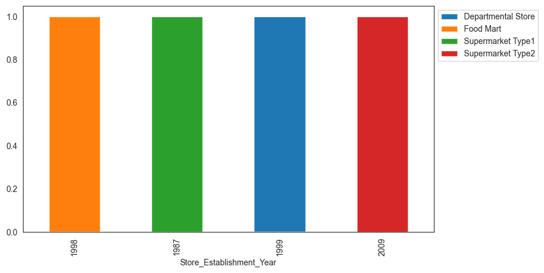

```python
stacked_barplot(dataset, "Store_Establishment_Year", "Store_Type")
```

```
Store_Location_City_Type  Tier 1  Tier 2  Tier 3   All
Store_Establishment_Year
1998                           0       0    1152  1152
All                         1349    6262    1152  8763
1987                           0    1586       0  1586
1999                        1349       0       0  1349
2009                           0    4676       0  4676
------------------------------------------------------------------------------------------------------------------------
```

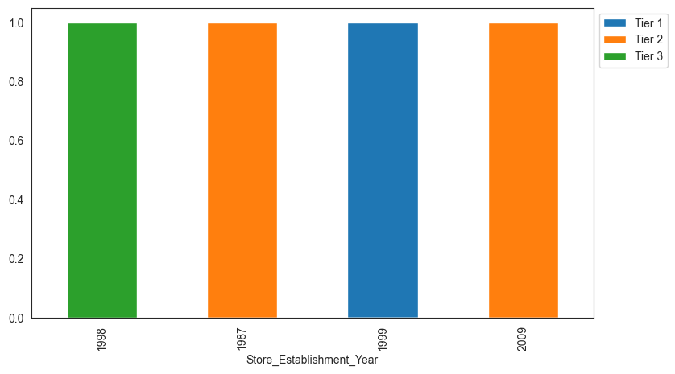

```python
stacked_barplot(dataset, "Store_Establishment_Year", "Store_Location_City_Type")
```

- Cohorts are tied to different city tiers: 1999 is Tier 1–heavy, 1987 and 2009 are Tier 2–heavy, and 1998 aligns with Tier 3, indicating non‑uniform geographic expansion across years.
- The visible association suggests establishment year influences city-tier placement.

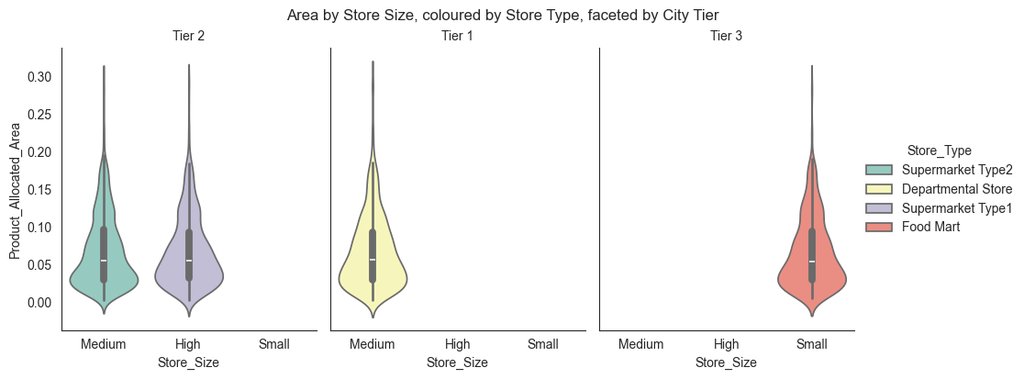

```python
features_to_plot = ['Store_Size', 'Store_Location_City_Type', 'Store_Type']

g = sns.catplot(
    data=dataset,
    x='Store_Size',
    y='Product_Allocated_Area',
    hue='Store_Type',
    col='Store_Location_City_Type',
    kind='violin',              # or 'violin', 'strip', etc.
    palette="Set3",
    height=4,
    aspect=0.8
)
g.set_titles(col_template="{col_name}")
g.fig.suptitle('Area by Store Size, coloured by Store Type, faceted by City Tier', y=1.02)
plt.show()
```

**Insights:**

# **Data Preprocessing**

#### Outlier Check

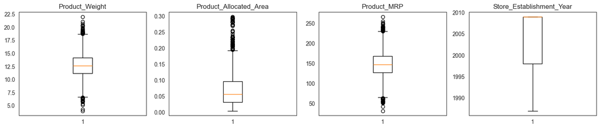

```python
# outlier detection using boxplot

plt.figure(figsize=(15, 12))

for i, variable in enumerate(numeric_features):
    plt.subplot(4, 4, i + 1)
    plt.boxplot(dataset[variable], whis=1.5)
    plt.tight_layout()
    plt.title(variable)

plt.show()
```

**Observations**

- There are quite a few outliers in the data.
- However, a light-touch approach is justified because the “outliers” look like legitimate business variation rather than data errors, and removing or capping them would risk discarding true demand/price signals while offering little modeling benefit.
- Diagnostics show long right tails for Allocated_Area and some high values for MRP/Weight, consistent with fat‑tailed retail phenomena where rare, high values are expected, flagging via the 1.5×IQR rule does not imply incorrectness.
- In retail, extreme promotions, premium SKUs, or limited shelf expansions are meaningful signals, aggressive winsorization/deletion can underfit by erasing these events.

#### Feature Engineering

**We can explore below features to see if they add any value.**

- Store_Age (Derived from Store_Establishment_Year)
  - Older stores may have established customer bases or different sales patterns reflecting maturity.
- Price_per_Weight (Ratio of Product_MRP to Product_Weight)
  - Captures the value density or cost efficiency of a product, may influence customer purchasing behavior and hence sales.
- Store_Performance (Average sales by Store_Id mapped as a feature)
  - Encodes store-level sales effectiveness and location-specific demand, acts as a proxy for store quality, footfall, or regional preferences.

```python
def quick_correlation_check(dataset, target_col):
    target = dataset[target_col]

    # Best current correlation
    numeric_cols = dataset.select_dtypes(include=['float64', 'int64']).columns
    current_best = dataset[numeric_cols].corrwith(target).abs().drop(target_col).max()

    # Test key engineered features
    store_age = datetime.now().year - dataset['Store_Establishment_Year']
    price_per_weight = dataset['Product_MRP'] / dataset['Product_Weight']
    store_perf = dataset['Store_Id'].map(dataset.groupby('Store_Id')[target_col].mean())

    engineered_best = max(
        abs(store_age.corr(target)),
        abs(price_per_weight.corr(target)),
        abs(store_perf.corr(target))
    )

    print(f"Current best correlation: {current_best:.4f}")
    print(f"Best engineered correlation: {engineered_best:.4f}")
    print(f"Improvement: {engineered_best - current_best:+.4f}")

    if engineered_best > current_best + 0.1:
        return "High Impact"
    elif engineered_best > 0.5:
        return "Useful"
    else:
        return "Low Impact"



def fast_model_impact_test(dataset, target_col):
    """Quick model-based validation of feature engineering impact"""

    y = dataset[target_col]
    X_baseline = dataset.drop(columns=[target_col])

    # Fast preprocessing
    def quick_encode(X):
        X = X.copy()
        le = LabelEncoder()
        for col in X.select_dtypes(include=['object']).columns:
            X[col] = le.fit_transform(X[col].astype(str))
        return X.fillna(X.mean())

    # Baseline performance
    X_processed = quick_encode(X_baseline)
    baseline_r2 = cross_val_score(
        RandomForestRegressor(n_estimators=20, random_state=42),
        X_processed, y, cv=3, scoring='r2'
    ).mean()

    # Add top engineered features
    X_engineered = X_baseline.copy()
    X_engineered['Store_Age'] = datetime.now().year - X_engineered['Store_Establishment_Year']
    X_engineered['Price_per_Weight'] = X_engineered['Product_MRP'] / X_engineered['Product_Weight']
    X_engineered['Store_Perf'] = dataset['Store_Id'].map(dataset.groupby('Store_Id')[target_col].mean())

    engineered_r2 = cross_val_score(
        RandomForestRegressor(n_estimators=20, random_state=42),
        quick_encode(X_engineered), y, cv=3, scoring='r2'
    ).mean()

    improvement = engineered_r2 - baseline_r2

    print(f"Baseline R²: {baseline_r2:.4f}")
    print(f"Engineered R²: {engineered_r2:.4f}")
    print(f"Improvement: {improvement:+.4f}")

    return "ADD FEATURES" if improvement > 0.01 else "SKIP FEATURES"
```

```python
correlation_check_recommendation = quick_correlation_check(dataset, 'Product_Store_Sales_Total')

if correlation_check_recommendation in ["High Impact", "Useful"]:
    model_recommendation = fast_model_impact_test(dataset, 'Product_Store_Sales_Total')
    print(f"Model Test Result: {model_recommendation}")
```

```
Current best correlation: 0.7880
Best engineered correlation: 0.8244
Improvement: +0.0364
Baseline R²: 0.9227
Engineered R²: 0.9221
Improvement: -0.0007
Model Test Result: SKIP FEATURES
```

**Observations**

- Our existing features provide a solid starting point.
- Even though Store_Age, Price_per_weight and Store_Perf showed good correlation to sales, modelling using same did not offer any benefit.
- We can stick to our original features.

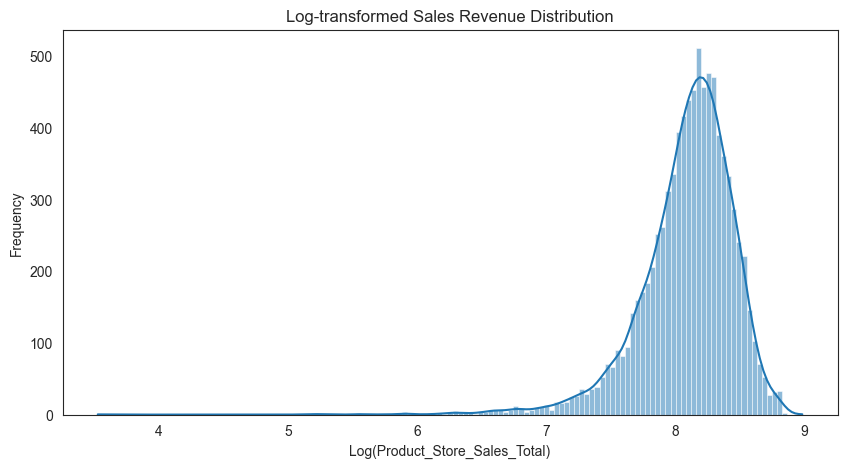

```python
log_sales_revenue = np.log1p(dataset['Product_Store_Sales_Total'])
plt.figure(figsize=(10, 5))
sns.histplot(log_sales_revenue, kde=True)
plt.title('Log-transformed Sales Revenue Distribution')
plt.xlabel('Log(Product_Store_Sales_Total)')
plt.ylabel('Frequency')
plt.show()
```

- Log of sales data has skewed the distribution with a long streched tail to the left
- Original distribution of sales was almost normal with very short tails, we can stick to original sales data for prediction

#### Data Cleaning

```python
dataset['Product_Sugar_Content'] = dataset['Product_Sugar_Content'].replace('reg', 'Regular')
```

- As we had observed during EDA, Product_Sugar_Content feature has some values marked as `reg` which needs to be merged with `Regular`

```python
dataset['Product_Sugar_Content'].value_counts()
```

```
Product_Sugar_Content
Low Sugar    4885
Regular      2359
No Sugar     1519
Name: count, dtype: int64
```

**Observations**

- Data cleaning is a one-time fix, not a transformation
- Pipeline should handle predictable transformations and hence keeping cleaning outside the pipeline

#### Preparing data for analysis

```python
# Define predictor matrix (X) using selected numeric and categorical features
X = dataset[numeric_features + categorical_features]

# Define target variable
y = dataset[target]
```

```python
# Split the dataset into training and test sets
X_train, X_test, y_train, y_test = train_test_split(
    X, y,              # Predictors (X) and target variable (y)
    test_size=0.2,     # 20% of the data is reserved for testing
    random_state=42    # Ensures reproducibility by setting a fixed random seed
)
```

#### Data Preprocessing Pipeline

```python
# Create a preprocessing pipeline for numerical and categorical features
preprocessor = make_column_transformer(
    (Pipeline([('num_imputer', SimpleImputer(strategy='median')),
               ('scaler', StandardScaler())]), numeric_features),
    (Pipeline([('cat_imputer', SimpleImputer(strategy='most_frequent')),
               ('encoder', OneHotEncoder(handle_unknown='ignore'))]), categorical_features)
)
```

- Pipeline will take care of encoding categorical features as well as scaling the numerical features

# **Model Building**

#### **Define functions for Model Evaluation**

```python
# function to compute adjusted R-squared
def adj_r2_score(predictors, targets, predictions):
    r2 = r2_score(targets, predictions)
    n = predictors.shape[0]
    k = predictors.shape[1]
    return 1 - ((1 - r2) * (n - 1) / (n - k - 1))


# function to compute different metrics to check performance of a regression model
def model_performance_regression(model, predictors, target):
    """
    Function to compute different metrics to check regression model performance

    model: regressor
    predictors: independent variables
    target: dependent variable
    """

    # predicting using the independent variables
    pred = model.predict(predictors)

    r2 = r2_score(target, pred)  # to compute R-squared
    adjr2 = adj_r2_score(predictors, target, pred)  # to compute adjusted R-squared
    rmse = np.sqrt(mean_squared_error(target, pred))  # to compute RMSE
    mae = mean_absolute_error(target, pred)  # to compute MAE
    mape = mean_absolute_percentage_error(target, pred)  # to compute MAPE

    # creating a dataframe of metrics
    df_perf = pd.DataFrame(
        {
            "RMSE": rmse,
            "MAE": mae,
            "R-squared": r2,
            "Adj. R-squared": adjr2,
            "MAPE": mape,
        },
        index=[0],
    )

    return df_perf
```

- R-squared: Captures the proportion of variance in sales explained by the features, giving a quick read on goodness-of-fit, however, it monotonically increases with more predictors and should not be used alone.
- Adjusted R-squared: Penalizes model complexity, enabling fair comparison across models with different numbers of predictors (useful when many dummies are added for stores, tiers, or categories).
- Using both RMSE and MAE balances sensitivity to large errors (RMSE) with robustness and interpretability (MAE), preventing a single metric from biasing model selection.
- R-squared and Adjusted R-squared summarize explanatory power, while the error metrics (RMSE/MAE/MAPE) quantify forecast accuracy in operational terms, covering fit, magnitude, and scale-free perspectives.

#### **Random Forest Regressor - Model Training Pipeline**

```python
# Define base Random Forest model
rf_model = RandomForestRegressor(random_state=42)

# Log transform the target variable for better model performance
#log_target = TransformedTargetRegressor(
#    regressor=rf_model,
#    func=np.log1p,          # log(1 + y)  → safer for zeros
#    inverse_func=np.expm1   # exp(x) - 1  → back to the original scale
#)

# Create pipeline with preprocessing and Random Forest model
rf_model_pipeline = make_pipeline(preprocessor, rf_model)
#rf_pipeline = make_pipeline(preprocessor, log_target)

# Train the model pipeline on the training data
rf_model_pipeline.fit(X_train, y_train)
```

```
Pipeline(steps=[('columntransformer',
                 ColumnTransformer(transformers=[('pipeline-1',
                                                  Pipeline(steps=[('num_imputer',
                                                                   SimpleImputer(strategy='median')),
                                                                  ('scaler',
                                                                   StandardScaler())]),
                                                  ['Product_Weight',
                                                   'Product_Allocated_Area',
                                                   'Product_MRP',
                                                   'Store_Establishment_Year']),
                                                 ('pipeline-2',
                                                  Pipeline(steps=[('cat_imputer',
                                                                   SimpleImputer(strategy='most_frequent')),
                                                                  ('encoder',
                                                                   OneHotEncoder(handle_unknown='ignore'))]),
                                                  ['Product_Sugar_Content',
                                                   'Product_Type', 'Store_Id',
                                                   'Store_Size',
                                                   'Store_Location_City_Type',
                                                   'Store_Type'])])),
                ('randomforestregressor',
                 RandomForestRegressor(random_state=42))])
```

```python
rf_estimator_model_train_perf = model_performance_regression(rf_model_pipeline, X_train, y_train)
print("Training performance \n")
rf_estimator_model_train_perf
```

```
Training performance
```

|  | RMSE | MAE | R-squared | Adj. R-squared | MAPE |
| --- | --- | --- | --- | --- | --- |
| 0 | 107.342381 | 40.539289 | 0.98984 | 0.989825 | 0.015169 |

```python
rf_estimator_model_test_perf = model_performance_regression(rf_model_pipeline, X_test, y_test)
print("Testing performance \n")
rf_estimator_model_test_perf
```

```
Testing performance
```

|  | RMSE | MAE | R-squared | Adj. R-squared | MAPE |
| --- | --- | --- | --- | --- | --- |
| 0 | 283.116701 | 108.945121 | 0.929751 | 0.929348 | 0.038806 |

**Observations**

- The random forest shows excellent in-sample fit but a sizeable generalization gap, indicating mild overfitting despite strong overall accuracy.
- Train vs test: R-squared/Adj-R² drop from ~0.990/0.990 to ~0.930/0.929, RMSE rises from ~107 to ~283, and MAPE from ~1.5% to ~3.9%, which is consistent with models that learn training detail more than signal.
- Test R² ≈ 0.93 and MAPE ≈ 3.9% are still strong for retail revenue forecasting, but the gap between train and test errors is a classic symptom of overfitting rather than data scarcity or underfit.

##### **Model Performance Improvement - Hyperparameter Tuning**

```python
# Choose the type of classifier.
rf_tuned = RandomForestRegressor(random_state=42)

# Create pipeline with preprocessing and XGBoost model
rf_pipeline = make_pipeline(preprocessor, rf_tuned)

# Grid of parameters to choose from
parameters = parameters = {
    'randomforestregressor__max_depth':[3, 4, 5, 6],
    'randomforestregressor__max_features': ['sqrt','log2', None],
    'randomforestregressor__n_estimators': [50, 75, 100, 125, 150]
}

# Type of scoring used to compare parameter combinations
scorer = metrics.make_scorer(metrics.r2_score)

# Run the grid search
grid_obj = GridSearchCV(rf_pipeline, parameters, scoring=scorer, cv=5)
grid_obj = grid_obj.fit(X_train, y_train)

# Set the clf to the best combination of parameters
rf_tuned = grid_obj.best_estimator_

# Fit the best algorithm to the data.
rf_tuned.fit(X_train, y_train)
```

```
Pipeline(steps=[('columntransformer',
                 ColumnTransformer(transformers=[('pipeline-1',
                                                  Pipeline(steps=[('num_imputer',
                                                                   SimpleImputer(strategy='median')),
                                                                  ('scaler',
                                                                   StandardScaler())]),
                                                  ['Product_Weight',
                                                   'Product_Allocated_Area',
                                                   'Product_MRP',
                                                   'Store_Establishment_Year']),
                                                 ('pipeline-2',
                                                  Pipeline(steps=[('cat_imputer',
                                                                   SimpleImputer(strategy='most_frequent')),
                                                                  ('encoder',
                                                                   OneHotEncoder(handle_unknown='ignore'))]),
                                                  ['Product_Sugar_Content',
                                                   'Product_Type', 'Store_Id',
                                                   'Store_Size',
                                                   'Store_Location_City_Type',
                                                   'Store_Type'])])),
                ('randomforestregressor',
                 RandomForestRegressor(max_depth=6, max_features=None,
                                       n_estimators=150, random_state=42))])
```

```python
rf_tuned_model_train_perf = model_performance_regression(rf_tuned, X_train, y_train)
print("Training performance \n")
rf_tuned_model_train_perf
```

```
Training performance
```

|  | RMSE | MAE | R-squared | Adj. R-squared | MAPE |
| --- | --- | --- | --- | --- | --- |
| 0 | 293.336953 | 155.229052 | 0.924124 | 0.924016 | 0.055745 |

```python
rf_tuned_model_test_perf = model_performance_regression(rf_tuned, X_test, y_test)
print("Testing performance \n")
rf_tuned_model_test_perf
```

```
Testing performance
```

|  | RMSE | MAE | R-squared | Adj. R-squared | MAPE |
| --- | --- | --- | --- | --- | --- |
| 0 | 315.425139 | 168.360176 | 0.912803 | 0.912303 | 0.059394 |

**Observation:**

- Before tuning, there was a substantial gap between the train and test R-squared values (~ 0.99 vs. ~ 0.93), indicating overfitting. After tuning, this gap has decreased (~ 0.92 vs. ~ 0.91), suggesting that the model is now generalizing better to unseen data.
- The R-squared on the test set has decreased from ~ 0.93 to ~ 0.91 after hyperparameter tuning. This indicates that tuned model is worse at predicting sales for unseen data.
- Tuning likely constrained tree complexity (e.g., shallower depth, larger min_samples_leaf), which curbed variance and generalization gap but introduced underfitting relative to the earlier model.

#### **XGBoost Regressor - Model Training Pipeline**

```python
# Define base XGBoost model
xgb_model = XGBRegressor(random_state=42)

# Create pipeline with preprocessing and XGBoost model
xgb_pipeline = make_pipeline(preprocessor, xgb_model)

# Train the model pipeline on the training data
xgb_pipeline.fit(X_train, y_train)
```

```
Pipeline(steps=[('columntransformer',
                 ColumnTransformer(transformers=[('pipeline-1',
                                                  Pipeline(steps=[('num_imputer',
                                                                   SimpleImputer(strategy='median')),
                                                                  ('scaler',
                                                                   StandardScaler())]),
                                                  ['Product_Weight',
                                                   'Product_Allocated_Area',
                                                   'Product_MRP',
                                                   'Store_Establishment_Year']),
                                                 ('pipeline-2',
                                                  Pipeline(steps=[('cat_imputer',
                                                                   SimpleImputer(strategy='most_frequent')),...
                              feature_types=None, gamma=None, grow_policy=None,
                              importance_type=None,
                              interaction_constraints=None, learning_rate=None,
                              max_bin=None, max_cat_threshold=None,
                              max_cat_to_onehot=None, max_delta_step=None,
                              max_depth=None, max_leaves=None,
                              min_child_weight=None, missing=nan,
                              monotone_constraints=None, multi_strategy=None,
                              n_estimators=None, n_jobs=None,
                              num_parallel_tree=None, random_state=42, ...))])
```

```python
xgb_estimator_model_train_perf = model_performance_regression(xgb_pipeline, X_train, y_train)
print("Training performance \n")
xgb_estimator_model_train_perf
```

```
Training performance
```

|  | RMSE | MAE | R-squared | Adj. R-squared | MAPE |
| --- | --- | --- | --- | --- | --- |
| 0 | 132.873337 | 62.735069 | 0.984431 | 0.984409 | 0.022233 |

```python
xgb_estimator_model_test_perf = model_performance_regression(xgb_pipeline, X_test,y_test)
print("Testing performance \n")
xgb_estimator_model_test_perf
```

```
Testing performance
```

|  | RMSE | MAE | R-squared | Adj. R-squared | MAPE |
| --- | --- | --- | --- | --- | --- |
| 0 | 310.109498 | 137.521286 | 0.915718 | 0.915234 | 0.050988 |

**Observation**:

- There is a noticeable difference between the train and test R-squared values (~ 0.98 vs. ~ 0.91), suggesting that the model may be slightly overfitting.
- By optimizing the model’s hyperparameters, we aim to reduce overfitting and improve performance on unseen data.

##### **Model Performance Improvement - Hyperparameter Tuning**

```python
# Choose the type of classifier.
xgb_tuned = XGBRegressor(random_state=42)

# Create pipeline with preprocessing and XGBoost model
xgb_pipeline = make_pipeline(preprocessor, xgb_tuned)

#Grid of parameters to choose from
param_grid = {
    'xgbregressor__n_estimators': [50, 100, 150, 200],    # number of trees to build
    'xgbregressor___max_depth': [2, 3, 4],    # maximum depth of each tree
    'xgbregressor___colsample_bytree': [0.4, 0.5, 0.6],    # percentage of attributes to be considered (randomly) for each tree
    'xgbregressor___colsample_bylevel': [0.4, 0.5, 0.6],    # percentage of attributes to be considered (randomly) for each level of a tree
    'xgbregressor___learning_rate': [0.01, 0.05, 0.1],    # learning rate
    'xgbregressor___reg_lambda': [0.4, 0.5, 0.6],    # L2 regularization factor
}

# Type of scoring used to compare parameter combinations
scorer = metrics.make_scorer(metrics.r2_score)

# Run the grid search
grid_obj = GridSearchCV(xgb_pipeline, param_grid, scoring=scorer,cv=5,n_jobs=-1)
grid_obj = grid_obj.fit(X_train, y_train)

# Set the clf to the best combination of parameters
xgb_tuned = grid_obj.best_estimator_

# Fit the best algorithm to the data.
xgb_tuned.fit(X_train, y_train)
```

```
Pipeline(steps=[('columntransformer',
                 ColumnTransformer(transformers=[('pipeline-1',
                                                  Pipeline(steps=[('num_imputer',
                                                                   SimpleImputer(strategy='median')),
                                                                  ('scaler',
                                                                   StandardScaler())]),
                                                  ['Product_Weight',
                                                   'Product_Allocated_Area',
                                                   'Product_MRP',
                                                   'Store_Establishment_Year']),
                                                 ('pipeline-2',
                                                  Pipeline(steps=[('cat_imputer',
                                                                   SimpleImputer(strategy='most_frequent')),...
                              device=None, early_stopping_rounds=None,
                              enable_categorical=False, eval_metric=None,
                              feature_types=None, gamma=None, grow_policy=None,
                              importance_type=None,
                              interaction_constraints=None, learning_rate=None,
                              max_bin=None, max_cat_threshold=None,
                              max_cat_to_onehot=None, max_delta_step=None,
                              max_depth=None, max_leaves=None,
                              min_child_weight=None, missing=nan,
                              monotone_constraints=None, ...))])
```

```python
xgb_tuned_model_train_perf = model_performance_regression(xgb_tuned, X_train, y_train)
print("Training performance \n")
xgb_tuned_model_train_perf
```

```
Training performance
```

|  | RMSE | MAE | R-squared | Adj. R-squared | MAPE |
| --- | --- | --- | --- | --- | --- |
| 0 | 185.315326 | 80.853314 | 0.969717 | 0.969674 | 0.029531 |

```python
xgb_tuned_model_test_perf = model_performance_regression(xgb_tuned, X_test, y_test)
print("Testing performance \n")
xgb_tuned_model_test_perf
```

```
Testing performance
```

|  | RMSE | MAE | R-squared | Adj. R-squared | MAPE |
| --- | --- | --- | --- | --- | --- |
| 0 | 304.748698 | 131.948767 | 0.918606 | 0.918139 | 0.048642 |

**Observation:**

- The gap between training and testing R-squared has decreased, indicating better generalization after hyperparameter tuning.
- Testing R-squared increased slightly, suggesting marginally better predictions on new data after tuning.

# **Model Performance Comparison, Final Model Selection, and Serialization**

```python
# training performance comparison

models_train_comp_df = pd.concat(
    [rf_estimator_model_train_perf.T,rf_tuned_model_train_perf.T,
    xgb_estimator_model_train_perf.T,xgb_tuned_model_train_perf.T],
    axis=1,
)

models_train_comp_df.columns = [
    "Random Forest Estimator",
    "Random Forest Tuned",
    "XGBoost",
    "XGBoost Tuned"
]

print("Training performance comparison:")
models_train_comp_df
```

```
Training performance comparison:
```

|  | Random Forest Estimator | Random Forest Tuned | XGBoost | XGBoost Tuned |
| --- | --- | --- | --- | --- |
| RMSE | 107.342381 | 293.336953 | 132.873337 | 185.315326 |
| MAE | 40.539289 | 155.229052 | 62.735069 | 80.853314 |
| R-squared | 0.989840 | 0.924124 | 0.984431 | 0.969717 |
| Adj. R-squared | 0.989825 | 0.924016 | 0.984409 | 0.969674 |
| MAPE | 0.015169 | 0.055745 | 0.022233 | 0.029531 |

```python
# Testing performance comparison

models_test_comp_df = pd.concat(
    [rf_estimator_model_test_perf.T,rf_tuned_model_test_perf.T,
    xgb_estimator_model_test_perf.T,xgb_tuned_model_test_perf.T],
    axis=1,
)

models_test_comp_df.columns = [
    "Random Forest Estimator",
    "Random Forest Tuned",
    "XGBoost",
    "XGBoost Tuned"
]

print("Testing performance comparison:")
models_test_comp_df
```

```
Testing performance comparison:
```

|  | Random Forest Estimator | Random Forest Tuned | XGBoost | XGBoost Tuned |
| --- | --- | --- | --- | --- |
| RMSE | 283.116701 | 315.425139 | 310.109498 | 304.748698 |
| MAE | 108.945121 | 168.360176 | 137.521286 | 131.948767 |
| R-squared | 0.929751 | 0.912803 | 0.915718 | 0.918606 |
| Adj. R-squared | 0.929348 | 0.912303 | 0.915234 | 0.918139 |
| MAPE | 0.038806 | 0.059394 | 0.050988 | 0.048642 |

```python
(models_train_comp_df - models_test_comp_df).iloc[2]
```

```
Random Forest Estimator    0.060088
Random Forest Tuned        0.011320
XGBoost                    0.068714
XGBoost Tuned              0.051111
Name: R-squared, dtype: float64
```

#### Checking best model on test data

```python
best_model_test_perf = model_performance_regression(rf_model_pipeline, X_test, y_test)
print("Best model performance on test data:")
best_model_test_perf
```

```
Best model performance on test data:
```

|  | RMSE | MAE | R-squared | Adj. R-squared | MAPE |
| --- | --- | --- | --- | --- | --- |
| 0 | 283.116701 | 108.945121 | 0.929751 | 0.929348 | 0.038806 |

#### Serializing the selected best model (Random Forest Estimator)

```python
# Create a folder for storing the files needed for web app deployment
os.makedirs("deployment_files", exist_ok=True)

# Define the file path to save (serialize) the trained model along with the data preprocessing steps
saved_model_path = "deployment_files/product_store_sales_prediction_model_v1_0.joblib"

# Save the best trained model pipeline using joblib
joblib.dump(rf_model_pipeline, saved_model_path)

print(f"Model saved successfully at {saved_model_path}")
```

```
Model saved successfully at deployment_files/product_store_sales_prediction_model_v1_0.joblib
```

#### Loading the serialized model

```python
# Load the saved model pipeline from the file
saved_model = joblib.load("deployment_files/product_store_sales_prediction_model_v1_0.joblib")

# Confirm the model is loaded
print("Model loaded successfully.")
```

```
Model loaded successfully.
```

```python
saved_model
```

```
Pipeline(steps=[('columntransformer',
                 ColumnTransformer(transformers=[('pipeline-1',
                                                  Pipeline(steps=[('num_imputer',
                                                                   SimpleImputer(strategy='median')),
                                                                  ('scaler',
                                                                   StandardScaler())]),
                                                  ['Product_Weight',
                                                   'Product_Allocated_Area',
                                                   'Product_MRP',
                                                   'Store_Establishment_Year']),
                                                 ('pipeline-2',
                                                  Pipeline(steps=[('cat_imputer',
                                                                   SimpleImputer(strategy='most_frequent')),
                                                                  ('encoder',
                                                                   OneHotEncoder(handle_unknown='ignore'))]),
                                                  ['Product_Sugar_Content',
                                                   'Product_Type', 'Store_Id',
                                                   'Store_Size',
                                                   'Store_Location_City_Type',
                                                   'Store_Type'])])),
                ('randomforestregressor',
                 RandomForestRegressor(random_state=42))])
```

#### Making predictions using serialized model

```python
saved_model.predict(X_test)
```

```
array([3192.4903, 3350.3913, 2413.5683, ..., 4144.8022, 2831.6704,
       4440.3056])
```

- Above results indicate that the model can be directly used for making predictions without any retraining.

# **Deployment**

The crux of our solution is to decouple the frontend and backend of the application for better accessibility and seamless integration with other services. This modular design enhances maintainability and scalability.

**Backend Development (Flask):**

1. We will develop a Flask application (app.py) responsible for:
- Loading the serialized Random Forest Estimator model we trained and saved as product_store_sales_prediction_model_v1_0.joblib.
- Exposing two API endpoints:
  - `/v1/sales`: For predicting the product store sales total of a single product, accepting input features as JSON, mirroring the data format used during training and EDA.
  - `/v1/salesbatch`: For batch predictions on multiple products, processing data uploaded as a CSV file, consistent with the dataset structure.
2. This backend handles the core prediction logic, applying the same data preprocessing steps (imputation, scaling, and encoding) used during model training to ensure consistency and accuracy. It returns predictions as JSON responses, facilitating easy integration with the frontend.
3. We'll deploy this Flask app, the serialized model, and the requirements.txt file to a Hugging Face Space using a Dockerfile. This makes the prediction service publicly accessible via a unique URL.

**Frontend Development (Streamlit):**

1. A separate Streamlit application (app.py) will serve as the user interface, tailored for SuperKart internal teams.
2. This frontend will include:
- Form-based inputs for online predictions, allowing users to enter product and store details like product weight, product mrp, store id etc., aligning with the features used in the model.
- A CSV file uploader for batch predictions, enabling users to analyze multiple products simultaneously, similar to the dataset format used for training.
3. The Streamlit app will use the `requests` library to communicate with the Flask API, sending input data and displaying predictions in a user-friendly format. This interaction facilitates a seamless user experience.
4. Similar to the backend, we'll deploy the Streamlit app to a Hugging Face Space using a `Dockerfile` with its own `requirements.txt` for managing dependencies.

Once deployed, SuperKart stakeholders can access the application through the frontend URL. They can input product/store details or upload a CSV file to obtain instant product store sales predictions, enabling data-driven pricing strategies. This decoupled approach ensures flexibility and ease of access for SuperKart internal teams.

## **Deployment - Backend**

### Flask Web Framework

```python
%%writefile backend_files/app.py
# Import necessary libraries
import numpy as np
import joblib  # For loading the serialized model
import pandas as pd  # For data manipulation
from flask import Flask, request, jsonify  # For creating the Flask API

# Initialize the Flask application
product_store_sales_predictor_api = Flask("Product Store Sales Predictor")

# Load the trained machine learning model
model = joblib.load("product_store_sales_prediction_model_v1_0.joblib")

# Define a route for the home page (GET request)
@product_store_sales_predictor_api.get('/')
def home():
    """
    This function handles GET requests to the root URL ('/') of the API.
    It returns a simple welcome message.
    """
    return "Welcome to the Product Store Sales Prediction API!"

# Define an endpoint for single product store sales prediction (POST request)
@product_store_sales_predictor_api.post('/v1/sales')
def predict_product_store_sales():
    """
    This function handles POST requests to the '/v1/rental' endpoint.
    It expects a JSON payload containing property details and returns
    the predicted rental price as a JSON response.
    """
    # Get the JSON data from the request body
    product_data = request.get_json()

    # Extract relevant features from the JSON data
    sample = {
        'Product_Id': product_data['Product_Id'],
        'Product_Weight': product_data['Product_Weight'],
        'Product_Sugar_Content': product_data['Product_Sugar_Content'],
        'Product_Allocated_Area': product_data['Product_Allocated_Area'],
        'Product_Type': product_data['Product_Type'],
        'Product_MRP': product_data['Product_MRP'],
        'Store_Id': product_data['Store_Id'],
        'Store_Establishment_Year': product_data['Store_Establishment_Year'],
        'Store_Size': product_data['Store_Size'],
        'Store_Location_City_Type': product_data['Store_Location_City_Type'],
        'Store_Type': product_data['Store_Type']
    }

    # Convert the extracted data into a Pandas DataFrame
    input_data = pd.DataFrame([sample])

    # Make prediction
    predicted_sales = model.predict(input_data)[0]

    # Convert predicted_sales to Python float
    predicted_sales = round(float(predicted_sales), 2)

    # Return the sales prediction as a JSON response
    return jsonify({'Predicted Product Store Sales': predicted_sales})


# Define an endpoint for batch prediction (POST request)
@product_store_sales_predictor_api.post('/v1/salesbatch')
def predict_rental_price_batch():
    """
    This function handles POST requests to the '/v1/salesbatch' endpoint.
    It expects a CSV file containing details for multiple products
    and returns the predicted product store sales as a dictionary in the JSON response.
    """
    # Get the uploaded CSV file from the request
    file = request.files['file']

    # Read the CSV file into a Pandas DataFrame
    input_data = pd.read_csv(file)

    # Make predictions for all properties in the DataFrame
    predicted_sales = model.predict(input_data).tolist()

    # Calculate sales
    predicted_sales = [round(float(sales), 2) for sales in predicted_sales]

    # Create a dictionary of predictions with product IDs as keys
    product_ids = input_data['Product_Id'].tolist()  # Assuming 'Product_Id' is the product ID column
    output_dict = dict(zip(product_ids, predicted_sales))  # Use actual prices

    # Return the predictions dictionary as a JSON response
    return output_dict

# Run the Flask application in debug mode if this script is executed directly
if __name__ == '__main__':
    product_store_sales_predictor_api.run(debug=True)
```

```
Overwriting backend_files/app.py
```

### Dependencies File

```python
%%writefile backend_files/requirements.txt
pandas==2.2.2
numpy==2.0.2
scikit-learn==1.6.1
xgboost==2.1.4
joblib==1.4.2
Werkzeug==2.2.2
flask==2.2.2
gunicorn==20.1.0
requests==2.28.1
uvicorn[standard]
streamlit==1.43.2
```

```
Writing backend_files/requirements.txt
```

### Dockerfile

```python
%%writefile backend_files/Dockerfile
FROM python:3.9-slim

# Set the working directory inside the container
WORKDIR /app

# Copy all files from the current directory to the container's working directory
COPY . .

# Install dependencies from the requirements file without using cache to reduce image size
RUN pip install --no-cache-dir --upgrade -r requirements.txt

# Define the command to start the application using Gunicorn with 4 worker processes
# - `-w 4`: Uses 4 worker processes for handling requests
# - `-b 0.0.0.0:7860`: Binds the server to port 7860 on all network interfaces
# - `app:app`: Runs the Flask app (assuming `app.py` contains the Flask instance named `product_store_sales_predictor_api`)
CMD ["gunicorn", "-w", "4", "-b", "0.0.0.0:7860", "app:product_store_sales_predictor_api"]
```

```
Writing backend_files/Dockerfile
```

### Setting up a Hugging Face Docker Space for the Backend

```python
# Import the login function from the huggingface_hub library
from huggingface_hub import login

# Login to your Hugging Face account using your access token
# Replace "YOUR_HUGGINGFACE_TOKEN" with your actual token
login(token="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")

# Import the create_repo function from the huggingface_hub library
from huggingface_hub import create_repo
```

```python
# Try to create the repository for the Hugging Face Space
try:
    create_repo("SuperkartSalesPredictionBackend",  # One can replace "Backend_Docker_space" with the desired space name
        repo_type="space",  # Specify the repository type as "space"
        space_sdk="docker",  # Specify the space SDK as "docker" to create a Docker space
        private=False  # Set to True if you want the space to be private
    )
except Exception as e:
    # Handle potential errors during repository creation
    if "RepositoryAlreadyExistsError" in str(e):
        print("Repository already exists. Skipping creation.")
    else:
        print(f"Error creating repository: {e}")
```

### Uploading Files to Hugging Face Space (Docker Space)

```python
# for hugging face space authentication to upload files
from huggingface_hub import HfApi

repo_id = "aiLearnerOnBudget/SuperkartSalesPredictionBackend"  # Your Hugging Face space id

# Initialize the API
api = HfApi()

# Upload Streamlit app files stored in the folder called deployment_files
api.upload_folder(
    folder_path="backend_files",  # Local folder path
    repo_id=repo_id,  # Hugging face space id
    repo_type="space",  # Hugging face repo type "space"
)
```

```
CommitInfo(commit_url='https://huggingface.co/spaces/aiLearnerOnBudget/SuperkartSalesPredictionBackend/commit/64a0b5e74c813e1b6c5d2f71566672de44092657', commit_message='Upload folder using huggingface_hub', commit_description='', oid='64a0b5e74c813e1b6c5d2f71566672de44092657', pr_url=None, repo_url=…
```

### **URL for flask backend**

- https://huggingface.co/spaces/aiLearnerOnBudget/SuperkartSalesPredictionBackend

## **Deployment - Frontend**

### Streamlit for Interactive UI

```python
# Create a folder for storing the files needed for frontend UI deployment
os.makedirs("frontend_files", exist_ok=True)
```

```python
%%writefile frontend_files/app.py
import streamlit as st
import pandas as pd
import requests

# Set the title of the Streamlit app
st.title("Superkart Product Store Sales Prediction")

# Section for online prediction
st.subheader("Online Prediction")

product_id = st.text_input("Product ID", "P0001")
product_weight = st.number_input("Product Weight", min_value=0.0, max_value=10000.0, value=0.0)
product_sugar_content = st.selectbox("Product Sugar Content", ['Low Sugar', 'Regular', 'No Sugar'])
product_allocated_area = st.number_input("Product Allocated Area", min_value=0.0, max_value=10000.0, value=0.0)
product_type = st.selectbox("Product Type", ['Frozen Foods', 'Dairy', 'Canned', 'Baking Goods',
       'Health and Hygiene', 'Snack Foods', 'Meat', 'Household',
       'Hard Drinks', 'Fruits and Vegetables', 'Breads', 'Soft Drinks',
       'Breakfast', 'Others', 'Starchy Foods', 'Seafood'])
product_mrp = st.number_input("Product MRP", min_value=0.0, max_value=10000.0, value=100.0)

store_id = st.text_input("Store ID", "S0001")
store_establishment_year = st.number_input("Store Establishment Year", min_value=1900, max_value=2025, value=2005, step=1)
store_size = st.selectbox("Store Size", ['Medium', 'High', 'Small'])
store_location_city_type = st.selectbox("Store Location City Type", ['Tier 2', 'Tier 1', 'Tier 3'])
store_type = st.selectbox("Store Type", ['Supermarket Type2', 'Departmental Store', 'Supermarket Type1', 'Food Mart'])


# Convert user input into a DataFrame
input_data = pd.DataFrame([{
    'Product_Id': product_id,
    'Product_Weight': product_weight,
    'Product_Sugar_Content': product_sugar_content,
    'Product_Allocated_Area': product_allocated_area,
    'Product_Type': product_type,
    'Product_MRP': product_mrp,
    'Store_Id': store_id,
    'Store_Establishment_Year': store_establishment_year,
    'Store_Size': store_size,
    'Store_Location_City_Type': store_location_city_type,
    'Store_Type': store_type
}])

# Make prediction when the "Predict" button is clicked
if st.button("Predict"):
    response = requests.post("https://aiLearnerOnBudget-SuperKartFrontend.hf.space/v1/sales", json=input_data.to_dict(orient='records')[0])  # Send data to Flask API
    if response.status_code == 200:
        print(response)
        prediction = response.json()['Predicted Product Store Sales']
        st.success(f"Predicted Product Store Sales : {prediction}")
    else:
        st.error("Error making prediction.")

# Section for batch prediction
st.subheader("Batch Prediction")

# Allow users to upload a CSV file for batch prediction
uploaded_file = st.file_uploader("Upload CSV file for batch prediction", type=["csv"])

# Make batch prediction when the "Predict Batch" button is clicked
if uploaded_file is not None:
    if st.button("Predict Batch"):
        response = requests.post("https://aiLearnerOnBudget-SuperKartFrontend.hf.space/v1/salesbatch", files={"file": uploaded_file})  # Send file to Flask API
        if response.status_code == 200:
            predictions = response.json()
            st.success("Batch predictions completed!")
            st.write(predictions)  # Display the predictions
        else:
            st.error("Error making batch prediction.")
```

```
Overwriting frontend_files/app.py
```

### Dependencies File

```python
%%writefile frontend_files/requirements.txt
pandas==2.2.2
requests==2.28.1
streamlit==1.43.2
```

```
Writing frontend_files/requirements.txt
```

### DockerFile

```python
%%writefile frontend_files/Dockerfile
# Use a minimal base image with Python 3.9 installed
FROM python:3.9-slim

# Set the working directory inside the container to /app
WORKDIR /app

# Copy all files from the current directory on the host to the container's /app directory
COPY . .

# Install Python dependencies listed in requirements.txt
RUN pip3 install -r requirements.txt

# Define the command to run the Streamlit app on port 8501 and make it accessible externally
CMD ["streamlit", "run", "app.py", "--server.port=8501", "--server.address=0.0.0.0", "--server.enableXsrfProtection=false"]

# NOTE: Disable XSRF protection for easier external access in order to make batch predictions
```

```
Writing frontend_files/Dockerfile
```

### Uploading Files to Hugging Face Space (Streamlit Space)

```python
# for hugging face space authentication to upload files
from huggingface_hub import HfApi

repo_id = "aiLearnerOnBudget/SuperKartFrontend"  # Your Hugging Face space id

# Initialize the API
api = HfApi()

# Upload Streamlit app files stored in the folder called deployment_files
api.upload_folder(
    folder_path="frontend_files",  # Local folder path
    repo_id=repo_id,  # Hugging face space id
    repo_type="space",  # Hugging face repo type "space"
)
```

```
CommitInfo(commit_url='https://huggingface.co/spaces/aiLearnerOnBudget/SuperKartFrontend/commit/3cef983fbe651f4a88869bf2cc8ef08b1dadf35c', commit_message='Upload folder using huggingface_hub', commit_description='', oid='3cef983fbe651f4a88869bf2cc8ef08b1dadf35c', pr_url=None, repo_url=RepoUrl('https…
```

### **URL for streamlit frontend**

https://huggingface.co/spaces/aiLearnerOnBudget/SuperKartFrontend

### Testing the flask backend locally

```python
# Lets take a sample row of the dataset to test the API
superkart_data.loc[0,:]
```

```
Product_Id                              FD6114
Product_Weight                           12.66
Product_Sugar_Content                Low Sugar
Product_Allocated_Area                   0.027
Product_Type                      Frozen Foods
Product_MRP                             117.08
Store_Id                                OUT004
Store_Establishment_Year                  2009
Store_Size                              Medium
Store_Location_City_Type                Tier 2
Store_Type                   Supermarket Type2
Product_Store_Sales_Total               2842.4
Name: 0, dtype: object
```

```python
model_url = "https://aiLearnerOnBudget-SuperkartSalesPredictionBackend.hf.space/v1/sales"

# Convert user input into a DataFrame
payload = {
    'Product_Id': "FD6114",
    'Product_Weight': 12.66,
    'Product_Sugar_Content': "Low Sugar",
    'Product_Allocated_Area': 0.027,
    'Product_Type': "Frozen Foods",
    'Product_MRP': 117.08,
    'Store_Id': "OUT004",
    'Store_Establishment_Year': 2009,
    'Store_Size': "Medium",
    'Store_Location_City_Type': "Tier 2",
    'Store_Type': "Supermarket Type2"
}


# Sending a POST request to the model endpoint with the test payload
response = requests.post(model_url, json=payload)

print(response)
```

```
<Response [200]>
```

```python
print(response.json())
```

[output not shown]

- As we can see, model is correctly predicting the product store sales value
- We are receiving a proper json response from the backend

### Look of app hosted on huggingface

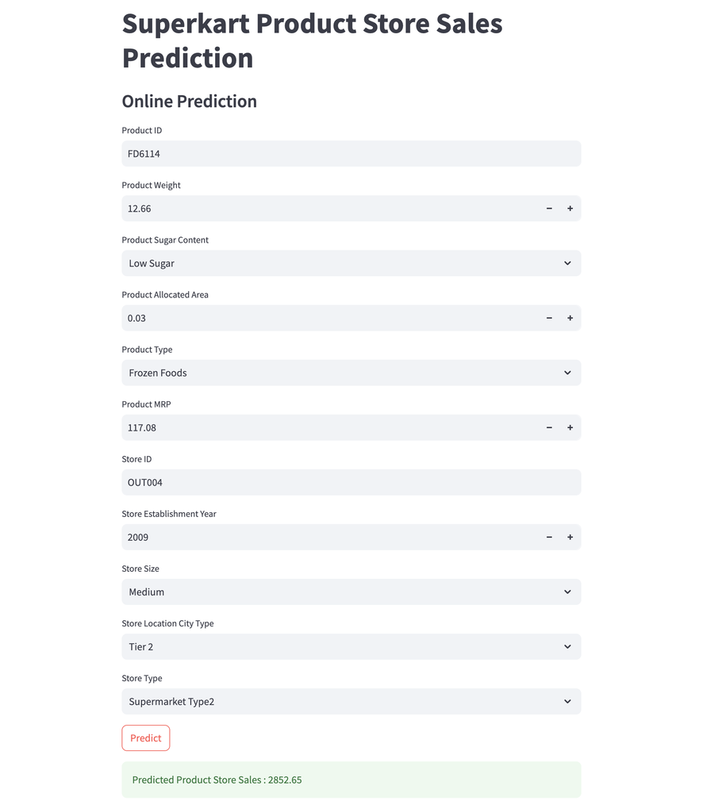

# **Actionable Insights and Business Recommendations**

### **Actionable insights**

- Price (Product_MRP) and pack size (Product_Weight) are the strongest positive sales drivers, while Product_Allocated_Area has little linear impact overall.
- Store attributes matter a lot, High stores consistently lead Medium and Small in median sales, and Tier 1 outperforms Tier 2 and Tier 3, indicating structural uplift from store format and location tier.
- Store identity effects are material, for example, OUT003 ranks highest on median performance while OUT002 lags, implying persistent, store-specific demand patterns that merit dedicated targeting.
- By format, Departmental Stores and Supermarket Type 1 outperform Food Marts on sales distributions, suggesting that the same product mix yields better returns in larger, full-line formats.
- Across product categories, medians are broadly similar with wide intra-category spread, a few groups (e.g., Others/Starchy/Breads/Soft Drinks) skew higher while Breakfast/Seafood skew lower, indicating mix opportunities rather than wholesale shifts.
- Sugar-content variants (Low/Regular/No) show comparable sales distributions
- The target distribution is already close to unimodal/normal, a log transform isn’t strictly needed
- The dataset is imbalanced (e.g., Tier 2 and Medium dominate counts, Supermarket Type 2 prevalent), and cohort effects exist by establishment year, so weighting/stratified evaluation is necessary for fair measurement and rollout planning.
- Apparent outliers largely reflect real retail variation (premium SKUs, promotions, space bursts), so aggressive trimming risks deleting signal, use robust evaluation and guardrails rather than blanket removal.
- For forecasting, the Random Forest Estimator delivers the best out-of-sample accuracy (lowest RMSE/MAE/MAPE and highest R²), while tuned XGBoost reduces variance with a slight accuracy trade‑off, giving a viable stability-first fallback.

### **Business recommendations**

- Pricing and pack-size laddering:
  - Optimize MRP and pack-size bands where elasticity and weight-led lift are strongest, prioritizing price–pack architecture tests over shelf-area changes that show weak marginal gains.
- Format and tier targeting:
  - Allocate budgets and inventory preferentially to High-format, Tier‑1 locations for new launches and hero SKUs, with Tier‑2 as scale channels and Tier‑3 focused on proven, fast-moving items only.
- Store-level playbooks:
  - Create targeted interventions by store ID (e.g., OUT003 growth programs, OUT002 turnaround plan) using tailored assortment, facings, and promotion cadence to exploit persistent store effects.
- Format mix and assortment:
  - Deepen Departmental Store and Supermarket Type‑1 ranges (broader assortment, secondary placements), while streamlining Food Mart ranges toward top movers and value SKUs.
- Category mix optimization:
  - Expand space and visibility in categories that skew higher (e.g., Starchy/Breads/Soft Drinks) and rationalize long tails in underperforming groups (e.g., Seafood/Breakfast) with regional exception rules.
- Data hygiene and governance:
  - Standardize categorical labels (e.g., merge “reg” into Regular), enforce reference taxonomies, and add schema checks in the ingestion pipeline to prevent downstream leakage of noisy classes.
- Cohort-aware rollouts:
  - Stagger promotions by establishment cohorts and city tier to reflect structural differences in format and demand, and evaluate uplifts with stratified A/B tests rather than aggregate reads.
- Forecasting deployment:
  - Productionize the Random Forest Estimator for primary forecasts and keep tuned XGBoost as a fallback in stability-critical contexts, monitor k‑fold/OOS performance with wMAPE as the business KPI.
- MLOps guardrails:
  - Track residual plots for heteroscedasticity, feature drift (tier/size/type shares), and label hygiene; schedule quarterly re‑tuning with stratified CV and retain robust metrics (RMSE/MAE/MAPE/R²) for balanced decisions.
- Test‑and‑learn program:
  - Prioritize experiments on price ladders, pack-size shifts, and format-specific facings rather than blanket space increases, given the weak area–sales linkage in the aggregate.